# Marketing Analytics

Sanjid Rahman

26/11/2021

## Existing features

ï..ID, Year_Birth, Education, Marital_Status, Income, Kidhome, Teenhome, Dt_Customer, Recency, MntWines, MntFruits, MntMeatProducts, MntFishProducts, MntSweetProducts, MntGoldProds, NumDealsPurchases, NumWebPurchases, NumCatalogPurchases, NumStorePurchases, NumWebVisitsMonth, AcceptedCmp3, AcceptedCmp4, AcceptedCmp5, AcceptedCmp1, AcceptedCmp2, Response, Complain, Country, Age

2213 rows and 29 columns

## New Features

- Total Amount Spent = MntWines + MntFruits + MntMeatProducts + MntFishProducts + MntSweetProducts + MntGoldProds
- Total Campaigns Accepted = AcceptedCmp1 + AcceptedCmp2 + AcceptedCmp3 + AcceptedCmp4 + AcceptedCmp5
- Total Number Of Purchases = NumDealsPurchases + NumCatalogPurchases + NumStorePurchases + NumWebPurchases
- Number of Dependents = Kidhome + Teenhome
- Number of Years as Customers = 2020- Dt_Customer

```r
df_regress<-df #%>%select(-ID,-Year_Birth,-Dt_Customer)
```

## Overview of the Y-Variable : Num Store Purchase

```r
summary(df$NumStorePurchases)
```

```
##    Min. 1st Qu.  Median    Mean 3rd Qu.    Max.
##   0.000   3.000   5.000   5.805   8.000  13.000
```

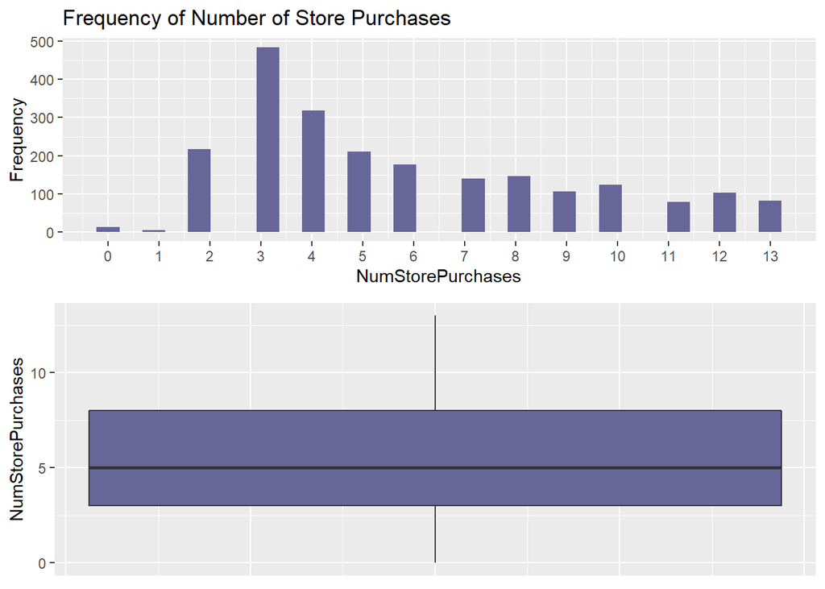

```r
p1<-df_regress%>%ggplot(aes(NumStorePurchases))+
  geom_histogram(fill="#666699")+
  scale_x_continuous(n.breaks=13)+
  ggtitle("Frequency of Number of Store Purchases")+
  ylab("Frequency")

p2<-df_regress%>%ggplot(aes(y=NumStorePurchases))+
  geom_boxplot(fill="#666699")+
  theme(axis.ticks.x=element_blank(),
        axis.text.x = element_blank())

grid.arrange(p1,p2,ncol=1)
```

## Visualize Correlation

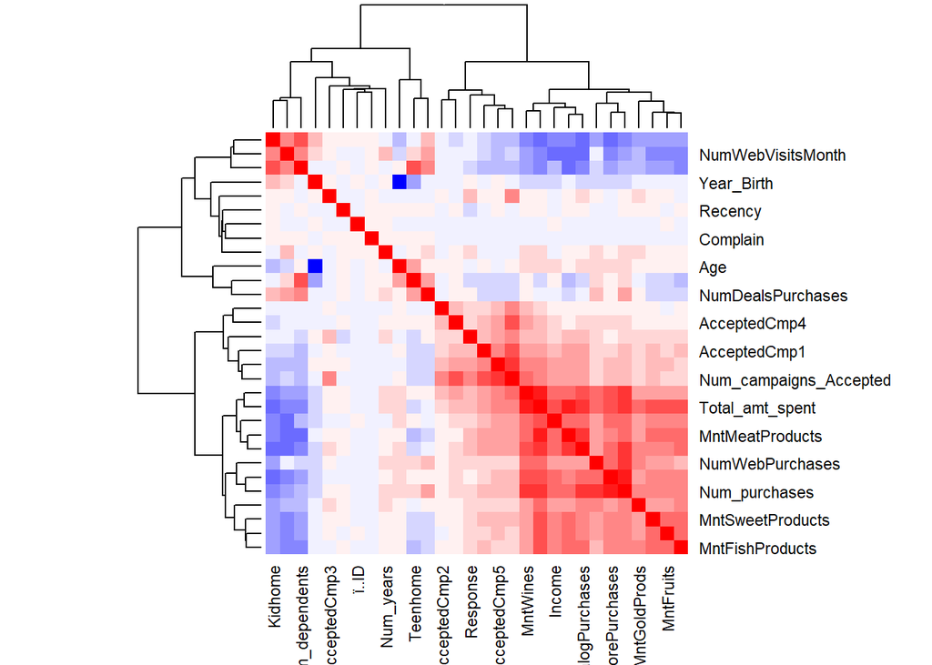

```r
library(caret)
df1<-select_if(df_regress,is.numeric)
correlation_matrix<-cor(df1)

#Visualise correlation in heatmap
col<- colorRampPalette(c("blue", "white", "red"))(20)
heatmap(correlation_matrix, col=col, symm=TRUE)
```

- Highly positively correlated variables are in Red and Highly negatively correlated variables are in Blue.
- We could see that income are positively correlated to Number of purchases and the amount of purchases.
- The different kind of purchases such as Meat purchases/ Sweet purchases/ Fish purchases/ Fruit purchases tend to be positively correlated to one another.
- There are negative correlations between having kids/ dependents at home and the amount or number of purchases.

#### Drop Highly correlated variables

```r
drop=findCorrelation(correlation_matrix,cutoff=0.8)
drop= c(drop)
corrdf<-data.frame(correlation_matrix)
col_drop<-corrdf%>%dplyr::select(drop)%>%colnames()
df_regress<-df_regress%>%select(-col_drop)
paste0("Columns dropped: ", col_drop)
```

```
## [1] "Columns dropped: Total_amt_spent" "Columns dropped: Num_purchases"
## [3] "Columns dropped: Age"
```

#### Numeric labeling: Convert to numerical representation

```r
#retrieve all non-numeric columns and represent these factors as integers.
library(tidyverse)
cat_var<-df_regress%>%select_if(negate(is.numeric))%>%colnames()
paste0("Categorical Variables : ", cat_var)
```

```
## [1] "Categorical Variables : Education"
## [2] "Categorical Variables : Marital_Status"
## [3] "Categorical Variables : Dt_Customer"
## [4] "Categorical Variables : Country"
```

```r
## [1] "Education"      "Marital_Status" "Country"

df_regress$Education1<-as.integer(factor(df_regress$Education))
df_regress%>%distinct(Education,Education1)
```

| Education | Education1 |
| --- | --- |
| Graduation | 3 |
| PhD | 5 |
| 2n Cycle | 1 |
| Master | 4 |
| Basic | 2 |

```r
df_regress$Marital_Status1<-as.integer(factor(df_regress$Marital_Status))
df_regress%>%distinct(Marital_Status,Marital_Status1)
```

| Marital_Status | Marital_Status1 |
| --- | --- |
| Divorced | 3 |
| Single | 5 |
| Married | 4 |
| Together | 6 |
| Widow | 7 |
| YOLO | 8 |
| Alone | 2 |
| Absurd | 1 |

```r
df_regress$Country1<-as.integer(factor(df_regress$Country))
df_regress%>%distinct(Country,Country1)
```

| Country | Country1 |
| --- | --- |
| SP | 7 |
| CA | 2 |
| US | 8 |
| AUS | 1 |
| GER | 3 |
| IND | 4 |
| SA | 6 |
| ME | 5 |

```r
df_regress1<-df_regress%>%select(-Education,-Marital_Status,-Country,-Num_campaigns_Accepted,-Num_dependents)
```

#### Split data into training (70%) & test datasets (30%)

```
## [1] "Number of rows in train dataset: 1551"
```

```
## [1] "Number of rows in test dataset: 662"
```

#### Perform Linear Regression & Interpret Results

#### Regression Results

```
##
## Call:
## lm(formula = NumStorePurchases ~ ., data = train_df)
##
## Residuals:
##      Min       1Q   Median       3Q      Max
## -10.7126  -0.9601  -0.1569   0.8645   6.7544
##
## Coefficients:
##                       Estimate Std. Error t value Pr(>|t|)
## (Intercept)          5.263e+00  1.543e+01   0.341 0.733153
## ï..ID                5.365e-06  1.615e-05   0.332 0.739857
## Year_Birth           1.250e-02  5.148e-03   2.428 0.015293 *
## Income               4.112e-06  2.755e-06   1.493 0.135706
## Kidhome             -6.388e-01  1.323e-01  -4.828 1.52e-06 ***
## Teenhome            -4.303e-02  1.231e-01  -0.350 0.726721
## Dt_Customer         -1.437e-03  6.492e-04  -2.214 0.026995 *
## Recency             -6.172e-03  1.895e-03  -3.256 0.001153 **
## MntWines             3.894e-03  2.804e-04  13.889  < 2e-16 ***
## MntFruits            4.024e-03  1.860e-03   2.163 0.030678 *
## MntMeatProducts     -7.602e-04  4.075e-04  -1.865 0.062327 .
## MntFishProducts      4.543e-03  1.428e-03   3.181 0.001495 **
## MntSweetProducts     7.142e-03  1.809e-03   3.948 8.24e-05 ***
## MntGoldProds         3.476e-03  1.263e-03   2.753 0.005981 **
## NumDealsPurchases    2.190e-01  3.532e-02   6.200 7.26e-10 ***
## NumWebPurchases      2.465e-01  2.779e-02   8.871  < 2e-16 ***
## NumCatalogPurchases -1.218e-01  3.135e-02  -3.884 0.000107 ***
## NumWebVisitsMonth   -3.866e-01  3.439e-02 -11.242  < 2e-16 ***
## AcceptedCmp3        -7.383e-01  2.135e-01  -3.458 0.000560 ***
## AcceptedCmp4         8.034e-02  2.341e-01   0.343 0.731475
## AcceptedCmp5        -4.560e-01  2.692e-01  -1.694 0.090547 .
## AcceptedCmp1        -3.780e-01  2.569e-01  -1.471 0.141380
## AcceptedCmp2         2.491e-01  4.760e-01   0.523 0.600849
## Response            -7.289e-01  1.813e-01  -4.019 6.12e-05 ***
## Complain             2.735e-01  5.251e-01   0.521 0.602478
## Num_years           -2.391e-01  1.866e-01  -1.281 0.200301
## Education1           2.998e-02  5.149e-02   0.582 0.560480
## Marital_Status1     -1.995e-02  4.916e-02  -0.406 0.684958
## Country1             3.529e-02  2.436e-02   1.449 0.147652
## ---
## Signif. codes:  0 '***' 0.001 '**' 0.01 '*' 0.05 '.' 0.1 ' ' 1
##
## Residual standard error: 2.07 on 1522 degrees of freedom
## Multiple R-squared:  0.6018, Adjusted R-squared:  0.5944
## F-statistic: 82.14 on 28 and 1522 DF,  p-value: < 2.2e-16
```

#### Plotting of all X-Variables’ P-value

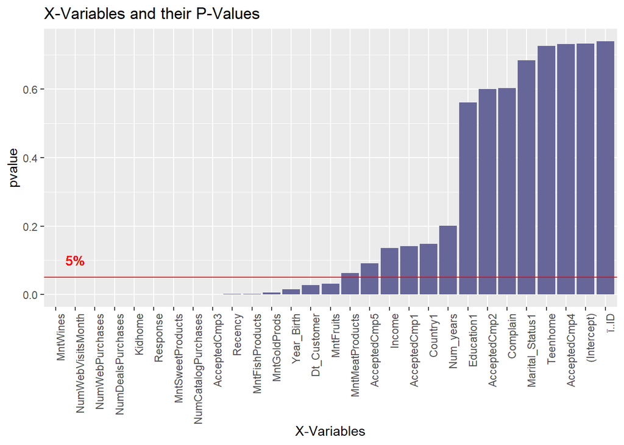

|  | pvalue | coefficient |
| --- | --- | --- |
| MntWines | 2.200280e-41 | 0.003893883 |
| NumWebVisitsMonth | 3.188565e-28 | -0.386622505 |
| NumWebPurchases | 1.994347e-18 | 0.246522105 |
| NumDealsPurchases | 7.255579e-10 | 0.218972630 |
| Kidhome | 1.516350e-06 | -0.638779684 |
| Response | 6.121174e-05 | -0.728868272 |

```
## [1] "RMSE: 2.18262620191988"
```

```
## [1] "R-square value on train dataset is: 0.60177"
```

```
## [1] "R-square value on test dataset is: 0.54926"
```

#### Plot the 5 significant X-variables with the Y-variable

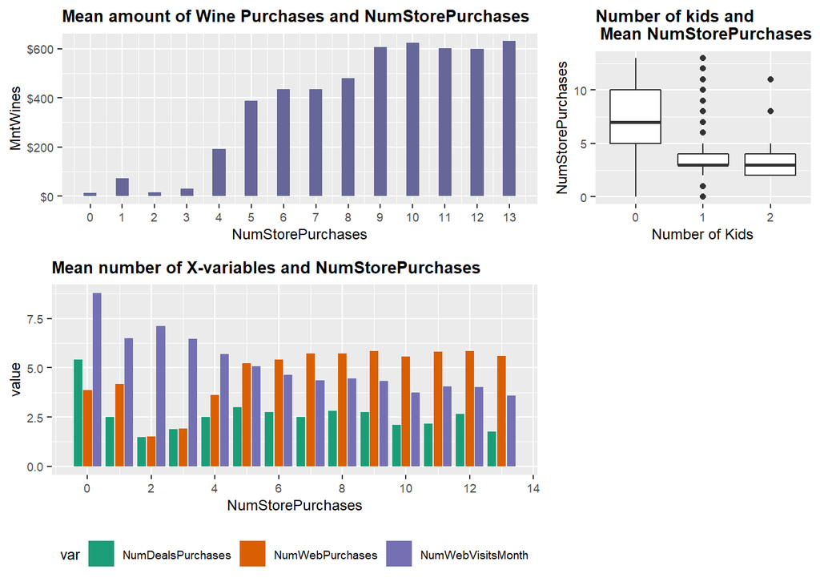

#### Observation:

- Amount spent on Wines increases as the Number of Store Purchases increases
- Number of Web Purchases increases as the Number of Store Purchases increases
- Number of Web Visits decreases as the Number of Store Purchases increases
- Mean Number of Store Purchases decreases when there are kids
- These observations suppors the regression model result which indicates positive coefficients for MntWines, NumWebPurchases and negative coefficients for KidHome and NumWebVisitsMonth